# VL10: Crossvalidierung, Regularisierung, SVM

IFM 5.6 Künstliche Intelligenz, 2017/18

Carsten Gips, FH Bielefeld

# Wiederholung

## Backpropagation

- Trainieren Sie das MLP mit dem Vektor $((0,1), (A,B))$. Nutzen Sie als Transferfunktion $g(a) = a^2$.

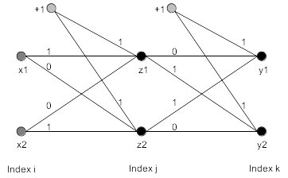

# Motivation

## Perzeptron mit optimaler Trennebene

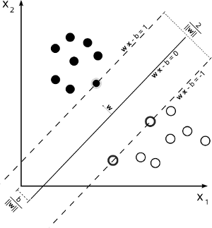

Quelle: [Cyc (*public domain*, en.wikipedia.org)](https://en.wikipedia.org/wiki/File:Svm_max_sep_hyperplane_with_margin.png)

## Themen für heute

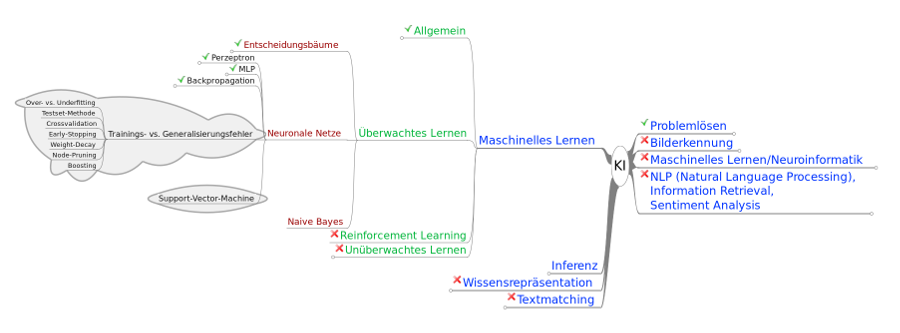

Am Ende der VL können/verstehen Sie:

- Trainings- vs. Generalisierungsfehler
  - Crossvalidierung zum Messen des Generalisierungsfehlers
  - Heuristiken zur Verbesserung der Leistung von MLPs
- Anwendungsbeispiele von MLP
- SVM: Perzeptron mit optimaler Trennebene im Hyperspace

# Training, Generalisierung und Overfitting

## Wie lange trainieren? Abbruchkriterium Trainingsfehler?

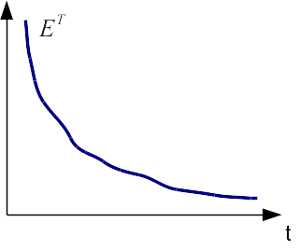

Trainingsfehler mit Trainingsdaten messen

## Trainingsfehler und Generalisierung

**Beobachtung**: Wenn Trainingsdaten “gut” und Netz mächtig genug (ausreichend viele Parameter), dann wird der Trainingsfehler im Laufe der Zeit gegen Null konvergieren.

**Frage**: Hat das Netz dann gute Generalisierungseigenschaften?

**Generalisierung**

> Fähigkeit, gute Vorhersagen zu machen (für unbekannte Daten)

> => Generalisierungsfehler: Maß für die Güte des Netzes

Generalisierungsfehler: Neue (nicht beim Lernen benutzte) Daten nutzen!

### Trainingsfehler und Generalisierung

Allgemein: Minimiere den Generalisierungsfehler unter Berücksichtigung der Verteilung der Daten: Wahrscheinlichkeit für Ausgabe $t$, gegeben den Input $\mathbf{x}$, multipliziert mit der Wahrscheinlichkeit für den Input $\mathbf{x}$

- **Generalisierungsfehler**:
  $$\begin{array}{rcl}
  E^G &=& \frac{1}{2} \int \! \int \left(y(\mathbf{x})-t\right)^2 p(\mathbf{x},t) dt\,d\mathbf{x}\\
  &=& \frac{1}{2} \int \! \int \left(y(\mathbf{x})-t\right)^2 p(t|\mathbf{x})p(\mathbf{x}) dt\,d\mathbf{x}\\
  &\approx& \frac{1}{2} \sum_{\beta=1}^p (y^{(\beta)} - t^{(\beta)})^2
  \end{array}$$

  Approximiere den Generalisierungsfehler durch die Messung der Vorhersageabweichung mit nicht beim Training genutzten Daten
- **Trainingsfehler**:
  $$E^T = \frac{1}{2} \sum_d (y^{(d)} - t^{(d)})^2 \stackrel{!}{=} \min$$

=> Generalisierungsfehler mit nicht beim Lernen benutzten Testbeispielen messen!

## Testset-Methode

1. Daten splitten in Trainingsdaten und Testdaten
2. Bestimmung der Parameter mit $E^T = \frac{1}{2} \sum_d (y^{(d)} - t^{(d)})^2 \stackrel{!}{=} \min$ (Nutzung der Trainingsdaten)
3. Generalisierungsfehler mit Testdaten: $E^G \approx \frac{1}{2p} \sum_{\beta=1}^p (y^{(\beta)} - t^{(\beta)})^2$ (*normalisierter* Fehler)

## Crossvalidierung: Messung des Generalisierungsfehlers

**Praxis**: Endlich viele Daten. Woher unabhängige Testbeispiele bekommen?

**Crossvalidierung**:

- Datensatz $D$ in $n$ gleich große Teile $D_j$ zerlegen
- Trainiere $n$ Kopien des Netzes
  - Lasse dabei jeweils einen anderen Teil $D_j$ beim Trainieren weg
  - Nutze ausgelassenen Teil $D_j$ zum Bestimmen des Testfehlers

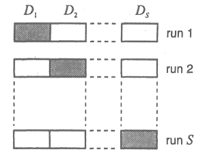

Quelle: Bishop: “Neural Networks for Pattern Recognition”, Oxford University Press

=> **Generalisierungsfehler ist Mittel über Testfehler**

## Netzarchitektur: Ausgewogene Parameteranzahl

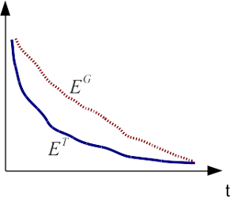

## Underfitting: Zu wenig Parameter

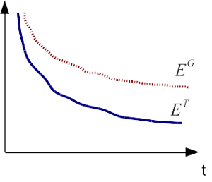

## Overfitting: Zu viele Parameter

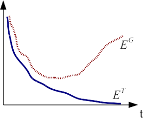

# Verbesserung der Generalisierungseigenschaften

## Gradientenabstieg

Finden des globalen Minimums nicht garantiert

- Problem in Praxis oft nicht so schlimm :-)
- Stochastischer Gradientenabstieg konvergiert in Praxis etwas schneller und zuverlässiger als normaler Gradientenabstieg
- Lernschrittweite $\eta$ “abkühlen”: $\eta \propto 1/t$

## Satz von Funahashi (1989)

Frage: Anzahl der Schichten?

> Jede stetige Funktion $y$ kann auf jedem kompakten (abgeschlossen, beschränkt) Intervall $K$ beliebig genau durch ein zweilagiges MLP approximiert werden.

*Anmerkung*: Zweilagiges MLP meint hier zwei Lagen mit Gewichten

## Training in der Praxis

Frage: Anzahl der Neurone?

- Faustregel (aus “VC-Dimension”[^1]): 10x soviele Daten wie Gewichte![^2]
- Praxis: Nimm Netz, welches zu mächtig ist und unternimm Maßnahmen.

## Praxis: Early Stopping

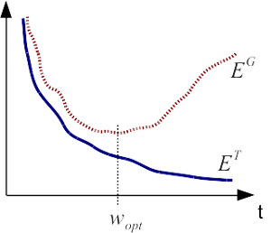

Early Stopping : Stoppe, wenn Generalisierungsfehler wieder steigt

Stoppe, wenn Overfitting beginnt!

**Implementierungsdetail**: Pflege Kopie des bisher besten Gewichtsvektors

## Crossvalidierung mit Early Stopping

- Datensatz $D$ in $n$ gleich große Teile $D_j$ zerlegen
- Trainiere $n$ Kopien des Netzes:
  - Lasse dabei jeweils einen anderen Teil $D_j$ beim Trainieren weg
  - Nutze ausgelassenen Teil $D_j$ zum Bestimmen des Testfehlers
  - Stoppe, sobald Testfehler wieder steigt (*Early Stopping*)
  - Liefere Zahl der Iterationen bis zum Stopp zurück
- Bilde Mittelwert über alle Iterationen: $\hat{i}$

=> Trainiere neues Netz mit allen Daten über genau $\hat{i}$ Iterationen

Tafel: Skizze Split Datensatz

## Gradientenabstieg mit Momentum

$$\Delta w_{ji}^{(t)} = -\eta \delta_j z_i + \alpha \Delta w_{ji}^{(t-1)}
\qquad \text{ mit } 0 \le \alpha < 1$$

$(t)$ bezeichnet den aktuellen Lernschritt, d.h. $\Delta w_{ji}^{(t)}$ ist das Delta der Gewichte im aktuellen Schritt und $\Delta w_{ji}^{(t-1)}$ ist entsprechend das Delta aus dem vorigen Schritt.

- Momentum-Term: $\alpha \Delta w_{ji}^{(t-1)}$
- Bedeutung: Behalte alte Abstiegs-Richtung abgeschwächt bei
  - Gebiete mit flacher Fehlerfunktion: Lernschrittweite wird effektiv größer
  - Gebiete mit steiler Fehlerfunktion: Abschwächung der Oszillation

    => individuell je Dimension $w_{ji}$ (Vergleich: $\eta$ ist für alle $w_{ji}$ identisch)

Tafel: Skizze Fehlerfunktion (flach, steil+Oszillation)

## Gradientenabstieg mit Weight-Decay (Regularisierung)

**Beobachtung**:

- Große Gewichte führen zu Overfitting (“Auswendiglernen” der Daten)

  => große Gewichte bestrafen

  **Neue Kostenfunktion** (Regularisierung):
  $$R = E^T + \lambda E^R \qquad \text{mit} \quad
  E^R = \frac{1}{2} \sum_i w_i^2$$

  $$\Delta w_i = -\eta \frac{\partial R}{\partial w_{i}} = -\eta \frac{\partial E^T}{\partial w_{i}} -\eta\lambda w_i$$
  - Große Gewichte sind “teurer” als kleine
  - Gewichte verschwinden, wenn nicht durch Daten unterstützt

## Node Pruning

1. Trainiere Netz bis Overfitting
2. Bestimme Wichtigkeitsmaß $s_i$ für jedes Neuron $i$:
   $$s_i = E^T_{\text{ohne Neuron i}} - E^T_{\text{mit Neuron i}}$$
3. Entferne Neuron mit kleinstem $s_i$
4. Trainiere Netz erneut, messe $E^G$ mit Testset
   - Sinkt $E^G$ (im Vergleich zu vorher): Gehe zu (2)
   - Anderenfalls: Stopp

## Boosting: Mehr aus den Daten herausholen

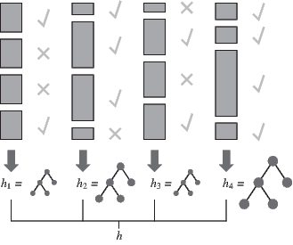

Quelle: [AIMA 3rd ed.](http://aima.cs.berkeley.edu)

- **Verfahren**: Nutze gewichteten Datensatz.
  - Trainiere Netz mit ursprünglichem Datensatz, starte mit Gewicht 1 für jeden Vektor
  - Gewichte falsch klassifizierte Daten höher, richtig klassifizierte Daten niedriger => Bspw. Anzahl der jeweiligen Datenvektoren anpassen
  - Trainiere *neues* Netz mit neuem Datensatz
  - Wiederhole vorige Schritte
- **Ergebnis**: Menge von MLPs, die den Datensatz unterschiedlich gut repräsentieren.
- **Nutzung**: Lasse MLPs parallel laufen:
  - Jedes MLP erhält den Eingabevektor
  - Ausgaben werden gewichtet gemäß dem jeweiligen Trainingsfehler

*Hinweis*: Hier nur die allgemeine Idee. Für die Details siehe Russell, Norvig: “Artificial Intelligence: A Modern Approach”

## Mixture of Experts

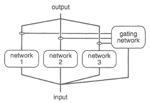

Quelle: Bishop: “Neural Networks for Pattern Recognition”, Oxford University Press

- Beispiel: Spurassistent
  - Eingabe: Bild der Straße
  - Aufgabe: Lenkwinkel so einstellen, dass Wagen in der Mitte der Spur bleibt
- Verschiedene Straßentypen:
  - Autobahn
  - Landstraße
  - Feldweg
1. Trainiere für jeden Straßentyp ein MLP (“Experte”)
2. Trainiere ein weiteres MLP: Welcher Experte ist in einer Situation zuständig
3. Nutzung: Alle MLP laufen parallel, Entscheider bestimmt, wer steuert Alternativ: Gewichteter Mittelwert aller Experten

# Anwendung MLP

## Autonome Fahrzeuge: Projekt ALVINN (1993)

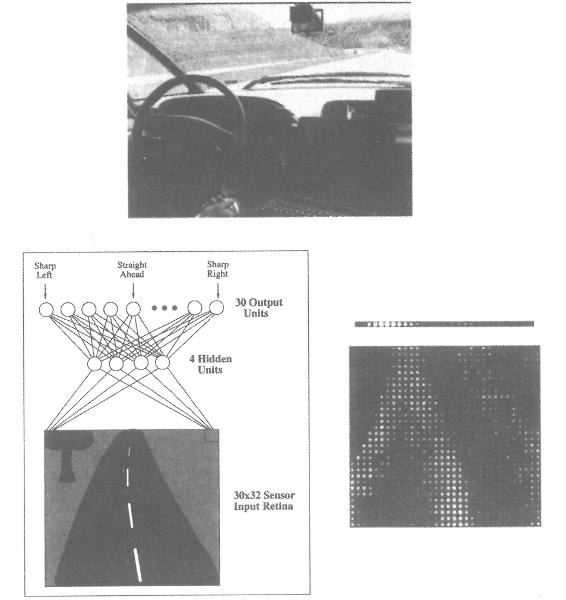

Quelle: Mitchell: “Machine Learning”, McGraw-Hill

- Aufgabe: Steuerung eines Fahrzeugs entlang einer Strasse mit Hilfe von Videokameras und Sensoren
- Input: Videobild von Strasse
- Output: Lenkwinkel
- Erfolg: Bis zu 70 Meilen/Stunde (normale Strasse)
- Später: Verschiedene Netze für verschiedene Strassentypen; ein Netz entscheidet über Gesamtausgabe (=> *Mixture of Experts*)

## Deep Learning: Google+ Photo

- Aufgabe: Lernen der 2.000 populärsten Google+-Fotokategorien
- Trainingsdaten: durch User gelabelte Fotos
- *Deep Convolutional Neural Network*:
  - 650.000 Neurone[^3]
  - 60 Millionen Parameter, eine Milliarde Verknüpfungen
- Training
  - 1.000 Rechner, insg. 16.000 CPUs
  - Pro Kategorie 5.000 Fotos
  - Eine Woche Rechenzeit zum Lernen

  Anmerkung: Mittlerweile weden *GPUs* für die effizientere Berechnung genutzt

Quelle: Andrea Trinkwalder: “Künstliche Bildversteher”, c’t 2014, Heft 9, ct.de/1409144

### Hintergrund “Deep Learning”

Beim Deep-Learning werden künstliche neuronale Netze analog zu Hirn-Arealen in Ebenen angeordnet, die immer komplexere Merkmale verwenden, um ein Bild zu erkennen.

Neben Backpropagation und **massiver Rechenleistung** sowie **riesigen Trainingsmengen** und **vielen versteckten Schichten** kommen weitere “Tricks” zur Anwendung: “Max Pooling” (Kombination von zu lernenden Features mit statistischen Methoden), “Dropout” (Teilnahme einer Neuronenschicht am Lernvorgang stochastisch bestimmt), “Convolution” (Faltung: Neurone reagieren auf überlappende Bereiche) …

=> “Viel hilft viel …”

Quellen: deeplearning.net/tutorial/lenet.html, en.wikipedia.org/wiki/Convolutional_neural_network, arxiv.org/abs/1409.1556

- Anmerkung: Deep Learning mittlerweile auch in Android und Siri (Spracherkennung) …
- Google: Durchbruch mit Deep Convolutional Neural Networks (Deep CNN) für Bilderkennung in 2012
- Was ist ein “tiefes” Netz?
  - 2012: Netze mit 8 Hidden Layers waren “tief”
  - 2015: Netze mit 20 bis 30 Hidden Layers gelten als “tief”
  - Anfang 2016: Microsoft “Projekt Oxford”: extrem tiefes Netz: über 100 Schichten

  Quelle: Andrea Trinkwalder: “Microsoft: Durchbruch in der Bilderkennung”, c’t 2016, Heft 2, ct.de/ydrd
- 2016: Google Translate basiert auf komplexem Neuronalen Netz: [heise.de/newsticker/meldung/Google-Translate-KI-uebersetzt-dank-selbst-erlernter-Sprache-3502351.html](https://www.heise.de/newsticker/meldung/Google-Translate-KI-uebersetzt-dank-selbst-erlernter-Sprache-3502351.html?view=print)

## Weitere Beispiele

- Handschrifterkennung bei US Post (Quelle: LeCun et. al. (1998), yann.lecun.com/exdb/mnist/)
- Verkaufszahlenprognose der BILD (Quelle: Riedmiller, Universität Freiburg, [Vorlesung “Maschinelles Lernen” 2012, Abschnitt MLP](http://ml.informatik.uni-freiburg.de/former/_media/documents/teaching/ss12/ml/05_mlps.printer.pdf))
- Vorlesen englischer Texte: NETtalk (Quelle: Sejnowski, Rosenberg: “NETtalk: a parallel network that learns to read aloud”, Technischer Bericht JHU/EECS-86/01, The John Hopkins University Electrical Engineering and Computer Science Technical Report (1986))
- Vorhersage Börsenkurse
- Steuerung eines Krans
- Diverse “Brain on a Chip”-Versuche
  - Modha (IBM): SyNAPSE-Projekt
  - Markram (EPFL): Blue Brain Projekt
  - Uni Heidelberg: Brainscales-Projekt

## “Brain on a Chip” vs. Menschliches Gehirn

- Bisher: ca. 200.000 künstliche Neuronen auf Chip
  - Vergleich: Kortex einer Katze: eine Milliarde Neuronen mit je 10.000 Synapsen
- Vergleich menschliches Gehirn:
  - Über 100 Milliarden Neuronen
  - Durchschnittlich etwa 1.000 Verbindungen pro Neuron
  - Weniger Energiebedarf als 20-Watt-Glühbirne, weniger als zwei Liter Volumen und weniger als drei Pfund Gewicht

Hinweis Vorverarbeitung (Physiologie), Verkörperte Intelligenz (Robotik)

Anmerkung: Aktuell werden neuronale Netze (i.d.R. “Deep CNN”) sehr effizient auf GPUs trainiert. Allerdings ist das immer noch Software, die auf einer Rechenmaschine ausgeführt wird. Ziel ist deshalb, die neuronalen Netze direkt in Hardware zu realisieren: “neuromorphe Chips”, die sich an der Arbeitsweise von Hirn-Neuronen orientieren. Dabei gibt es verschiedene Herangehensweisen: von der direkten Übertragung der Software-Netze in (digitaler) Hardware über die Simulation von Differentialgleichungssystemen bis hin zu analoger Hardware, die näher an den tatsächlichen Prozessen im Gehirn ist.

### Brain on a Chip I: SyNAPSE-Projekt

Modha (IBM): SyNAPSE-Projekt

### Brain on a Chip II: Blue Brain Projekt

Markram (EPFL): Blue Brain Projekt

- Aufwendige Simulationen von Neuronen mit Zellkörper, Synapsen und Axonen, Verteilung und Typ der Ionenkanäle in den Zellmembranen etc.
- Simulation mit Hilfe der Differentialgleichungen von Alan Hodgkin und Andrew Huxley (Nobelpreis 1963)
- 2007 Simulation einer kortikalen Säule des Gehirns einer Ratte
- Ankündigung: 2023 komplette Simulation des menschlichen Gehirns

### Brain on a Chip III: Brainscales-Projekt

Brainscales-Projekt ([brainscales.kip.uni-heidelberg.de](http://brainscales.kip.uni-heidelberg.de/index.html))

- Simulation von Neuronen mit Hilfe analoger elektronischer Schaltungen
- 2010 Chip mit rund 200.000 künstlichen Neuronen

### Brain on a Chip IV: Menschliches Gehirn

- Über 100 Milliarden Neuronen
- Durchschnittlich etwa 1000 Verbindungen pro Neuron
- Weniger Energiebedarf als 20-Watt-Glühbirne, weniger als zwei Liter Volumen und weniger als drei Pfund Gewicht

### Brain on a Chip V: Probleme

- Komplexität (Anzahl, Verschaltung, Berechnung) des Gehirns
- Verständnis der Physiologie: Wozu dienen die Glia-Zellen? Wie sind Areale verschaltet (Architektur)?
- Abstraktionen für Simulationen nötig
- Lernen mit Daten und Rückmeldung
- Robotik: “Verkörperte Intelligenz”
- Energiebedarf

Hinweis Komprimierung/Vorverarbeitung

### Einige Quellen

- [heise.de/tp/artikel/35/35342](https://www.heise.de/tp/artikel/35/35342/1.html)
- heise.de/ix/meldung/Gehirnchip-macht-bei-IBM-Fortschritte-1326868.html
- heise.de/tr/artikel/IBMs-neuer-Chip-rechnet-fast-wie-wir-1333507.html
- ct.de/1204086
- ct.de/1312026
- ct.de/1311084

## Kurzweils “Singularität”

- Prognose, ab wann Computer ein für allemal die menschliche Intelligenz übertreffen
- Datum mehrfach geändert, zuletzt auf **2045**[^4]
- Basis: im Wesentlichen Vergleich der Anzahl von Berechnungselementen in Gehirnen (Neuronen) und in Computern (Transistoren)
- Warnung vor Folgen: Kontrollverlust, totalitäre Gesellschaft

  spektrum.de/news/wie-algorithmen-und-big-data-unsere-zukunft-bestimmen/1375933

# Lineare Separation in höheren Dimensionen: SVM

## Lineare Separatoren mittels Hyperebenen

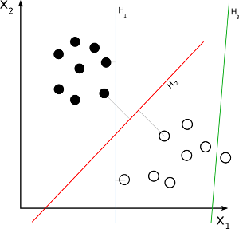

Quelle: ZackWeinberg, Cyc (CC BY-SA 3.0, en.wikipedia.org)

## Idee: Maximiere den Abstand (Margin)

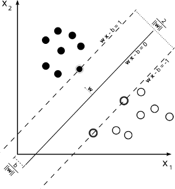

Quelle: [Cyc (*public domain*, en.wikipedia.org)](https://en.wikipedia.org/wiki/File:Svm_max_sep_hyperplane_with_margin.png)

## Lineare Separatoren mit Margin

[figure not shown]

Quelle: [Cyc (public domain, en.wikipedia.org)](https://en.wikipedia.org/wiki/File:Svm_max_sep_hyperplane_with_margin.png)

- Gesucht: $y_i = f(\mathbf{x}_i) = \operatorname{sgn}\left(\langle\mathbf{w},\mathbf{x}_i\rangle - b \right)\;\;$
  - Gewichte als Linearkombination der Trainingsbeispiele: $\;\;\mathbf{w} = \sum_j \alpha_j y_j \mathbf{x}_j$
  - Nur wichtige Beispiele $\mathbf{x}_j$ merken: “Support Vectors”, für alle anderen ist $\alpha_j = 0$
  - => $f(\mathbf{x}_i) = \operatorname{sgn}(\sum_j \alpha_j y_j\langle\mathbf{x}_j,\mathbf{x}_i\rangle - b )$
- Optimierungsproblem bzgl. der $\alpha_j$: $\;\;\; \operatorname{argmax}_{\alpha} \; \sum_j \alpha_j - \frac{1}{2} \sum_{j,k} \alpha_j \alpha_k y_j y_k \langle \mathbf{x}_j, \mathbf{x}_k \rangle$

  mit $\alpha_j \ge 0$ und $\sum_j \alpha_j y_j = 0$

  (Einsatz von Lagrange-Multiplikatoren und Karush-Kuhn-Tucker-Bedingungen)

## Erinnerung: XOR mit linearer Trennebene

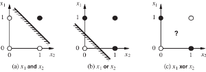

Quelle: [AIMA 3rd ed.](http://aima.cs.berkeley.edu)

- Einführung neuer Merkmale $F(\mathbf{x})$:
  - $f_1 = x_1^2$
  - $f_2 = x_2^2$
  - $f_3 = \sqrt{2}x_1x_2$

| $x_1$ | $x_2$ | $k$ | $f_1$ | $f_2$ | $f_3$ |
| --- | --- | --- | --- | --- | --- |
| 0 | 0 | 0 | 0 | 0 | 0 |
| 0 | 1 | 1 | 0 | 1 | 0 |
| 1 | 0 | 1 | 1 | 0 | 0 |
| 1 | 1 | 0 | 1 | 1 | 1.4142 |

*Beobachtung*: (für den obigen Fall)
$$\begin{array}{rcl}
\langle F(\mathbf{a}), F(\mathbf{b}) \rangle &=& \langle (a_1^2, a_2^2, \sqrt{2}a_1a_2), (b_1^2, b_2^2, \sqrt{2}b_1b_2) \rangle \\
&=& a_1^2b_1^2 + a_2^2b_2^2 + \sqrt{2}a_1a_2\sqrt{2}b_1b_2 \\
&=& a_1^2b_1^2 + a_2^2b_2^2 + 2a_1a_2b_1b_2 \\
&=& a_1^2b_1^2 + a_2^2b_2^2 + 2a_1b_1a_2b_2 \\
&=& (a_1b_1 + a_2b_2)^2 = \langle \mathbf{a}, \mathbf{b} \rangle^2
\end{array}$$

## SVM: Kernel-Trick

1. Gewichte aus Support-Vektoren zusammenbauen: $\mathbf{w} = \sum_j \alpha_j y_j \mathbf{x}_j$
2. Optimierungsproblem bzgl. der $\alpha_j$ lösen
3. Klassifikator: $f(\mathbf{x}_i) = \operatorname{sgn}\left(\langle\mathbf{w},\mathbf{x}_i\rangle - b \right) = \operatorname{sgn}\left(\sum_j \alpha_j y_j\langle\mathbf{x}_j,\mathbf{x}_i\rangle - b \right)$
4. Ersetze $\mathbf{x}$ durch $F(\mathbf{x})$ => Übergang in höherdimensionalen Raum
   - XOR-Beispiel von vorhin: $\langle F(\mathbf{x}_j),F(\mathbf{x}_i) \rangle = (\langle\mathbf{x}_j,\mathbf{x}_i\rangle)^2$
   - Nicht erst transformieren und dann Skalarprodukt bilden! => Stattdessen einfache Operation auf Skalarprodukt von $\mathbf{x}_i$ und $\mathbf{x}_j$!
   - Ausdruck $(\langle\mathbf{x}_j,\mathbf{x}_i\rangle)^2$ nennt sich (quadratischer) Kernel : $K(\mathbf{x}_j,\mathbf{x}_i)$
   - Andere Kernel: zB. **polynomialer Kernel**: $K(\mathbf{x}_j,\mathbf{x}_i) = (1+\langle\mathbf{x}_j,\mathbf{x}_i\rangle)^d$

Support Vector Machine : Lineare Trennung in höheren Dimensionen

# Zusammenfassung

## tl;dr

- Trainingsfehler vs. Generalisierung
  - Trainingsfehler kein geeignetes Abbruchkriterium
  - Generalisierungsfehler mit unabhängiger Testmenge bestimmen
  - Wenige Daten: Crossvalidierung
  - Over- und Underfitting, Zusammenhang zu Parameterzahl
- Early Stopping, Momentum, Weight Decay, Node Pruning
- Boosting
- Mixture of Experts
- Support Vector Machines

**Nächste Woche**: PK1: Syntax+Semantik, Folgern

## Literatur zum Weiterlesen

- Russell, Norvig: “Artificial Intelligence: A Modern Approach, 3rd ed.”
  - Generalisierung und Overfitting, Early Stopping: Abschnitte 18.3.5, 18.7.5
  - Crossvalidierung: Abschnitt 18.4
  - Regularisierung: Abschnitt 18.4.3
  - Boosting: Abschnitt 18.10
  - SVM: Abschnitt 18.9
- Bishop: “Neural Networks for Pattern Recognition”, Oxford University Press
  - Early Stopping, Regularisierung, Pruning, Mixture of Experts: Kapitel 9 “Learning and Generalization”

## Lernziele – Nach dieser Vorlesung sollten Sie …

### Verstehen (K2)

- Unterschied Trainings- und Generalisierungsfehler
- Verfahren Weight Decay, Momentum, Boosting, Mixture of Experts
- Prinzipien hinter SVM

### Anwenden (K3)

- Nutzung des Generalisierungsfehlers als Abbruchkriterium
- Umgang mit Crossvalidierung zur Messung des Generalisierungsfehlers
- Einsatz von Early Stopping

## Diese Fragen sollten Sie beantworten können …

### Training und Generalisierung

- Was ist der Unterschied zwischen Trainings- und Generalisierungsfehler?
- Warum sollte man nicht unbedingt trainieren, bis der Trainingsfehler Null wird?
- Was ist der Unterschied zwischen Over- und Underfitting?
- Wie berechnet man den Generalisierungsfehler?
- Wie gelangt man in der Praxis (endliche Daten!) an eine unabhängige Testdatenmenge?
- Erläutern Sie das Verfahren “Crossvalidierung”.

### Regularisierung und andere Verbesserungen

- Was bedeutet “early stopping”? Wie kann man mit Crossvalidierung die Anzahl der Iterationen bestimmen?
- Erklären Sie Ziel und Umsetzung von Gradientenabstieg mit Momentum-Term.
- Erklären Sie Ziel und Umsetzung von Gradientenabstieg mit Weight Decay.
- Was ist Boosting? Wie funktioniert das?

### Support Vector Machine (SVM)

- Was sind Support Vectors? Wozu werden sie verwendet?
- Was ist ein Kernel? Warum ist der Einsatz von Kernel von Vorteil?
[^1]: Vapnik–Chervonenkis Dimension, vgl. en.wikipedia.org/wiki/VC_dimension
[^2]: vgl. Bishop: “Neural Networks for Pattern Recognition”
[^3]: Vergleich: Menschliches Hirn: ca. 100 Milliarden … 1 Billion Nervenzellen
[^4]: de.wikipedia.org/wiki/Menschheit_2.0